# HR source

yeonxxi

2021 9 13

#### 설치 및 데이터 불러오기

```r
install.packages("ggplot2", repos = "http://cran.us.r-project.org")
install.packages("readxl", repos = "http://cran.us.r-project.org")
library(dplyr)
library(ggplot2)
library(readxl)

getwd()
```

```
## [1] "D:/지연/easy_r"
```

```r
setwd("D:/지연/easy_r")
getwd()
```

```
## [1] "D:/지연/easy_r"
```

```r
raw_HR <- read.csv("HR_comma_sep.csv")
HR <- raw_HR
```

repos = “http://cran.us.r-project.org” 를 입력하여 마크다운시 정상출력 오류 해결

다음과 같이 데이터를 확인해볼 수 있다.

```r
summary(HR)
```

```
##  satisfaction_level last_evaluation  number_project  average_montly_hours
##  Min.   :0.0900     Min.   :0.3600   Min.   :2.000   Min.   : 96.0
##  1st Qu.:0.4400     1st Qu.:0.5600   1st Qu.:3.000   1st Qu.:156.0
##  Median :0.6400     Median :0.7200   Median :4.000   Median :200.0
##  Mean   :0.6128     Mean   :0.7161   Mean   :3.803   Mean   :201.1
##  3rd Qu.:0.8200     3rd Qu.:0.8700   3rd Qu.:5.000   3rd Qu.:245.0
##  Max.   :1.0000     Max.   :1.0000   Max.   :7.000   Max.   :310.0
##  time_spend_company Work_accident         left        promotion_last_5years
##  Min.   : 2.000     Min.   :0.0000   Min.   :0.0000   Min.   :0.00000
##  1st Qu.: 3.000     1st Qu.:0.0000   1st Qu.:0.0000   1st Qu.:0.00000
##  Median : 3.000     Median :0.0000   Median :0.0000   Median :0.00000
##  Mean   : 3.498     Mean   :0.1446   Mean   :0.2381   Mean   :0.02127
##  3rd Qu.: 4.000     3rd Qu.:0.0000   3rd Qu.:0.0000   3rd Qu.:0.00000
##  Max.   :10.000     Max.   :1.0000   Max.   :1.0000   Max.   :1.00000
##     sales              salary
##  Length:14999       Length:14999
##  Class :character   Class :character
##  Mode  :character   Mode  :character
##
##
##
```

```r
str(HR)
```

```
## 'data.frame':    14999 obs. of  10 variables:
##  $ satisfaction_level   : num  0.38 0.8 0.11 0.72 0.37 0.41 0.1 0.92 0.89 0.42 ...
##  $ last_evaluation      : num  0.53 0.86 0.88 0.87 0.52 0.5 0.77 0.85 1 0.53 ...
##  $ number_project       : int  2 5 7 5 2 2 6 5 5 2 ...
##  $ average_montly_hours : int  157 262 272 223 159 153 247 259 224 142 ...
##  $ time_spend_company   : int  3 6 4 5 3 3 4 5 5 3 ...
##  $ Work_accident        : int  0 0 0 0 0 0 0 0 0 0 ...
##  $ left                 : int  1 1 1 1 1 1 1 1 1 1 ...
##  $ promotion_last_5years: int  0 0 0 0 0 0 0 0 0 0 ...
##  $ sales                : chr  "sales" "sales" "sales" "sales" ...
##  $ salary               : chr  "low" "medium" "medium" "low" ...
```

코드 입력상 이름이 길어지므로 이름을 재설정한다

```r
HR <- rename(HR,
             SL = satisfaction_level, # 직무만족도
             LE = last_evaluation,    # 마지막 평가점수
             NP = number_project,     # 진행 프로젝트 수
             AM = average_montly_hours, # 월평균 근무시간
             TS = time_spend_company, # 근속년수
             WA = Work_accident,      # 사건사고 여부 (0:없음, 1:있음)
             PL = promotion_last_5years) # 최근 5년간 승진여부 (0:승진x, 1:승진o)
```

# 1. 부서별 임금에 따른 직무 만족도 수준 : 임금이 높을수록 직무 만족도가 높을 것

#### 변수 검토

```r
table(HR$salary)
```

```
##
##   high    low medium
##   1237   7316   6446
```

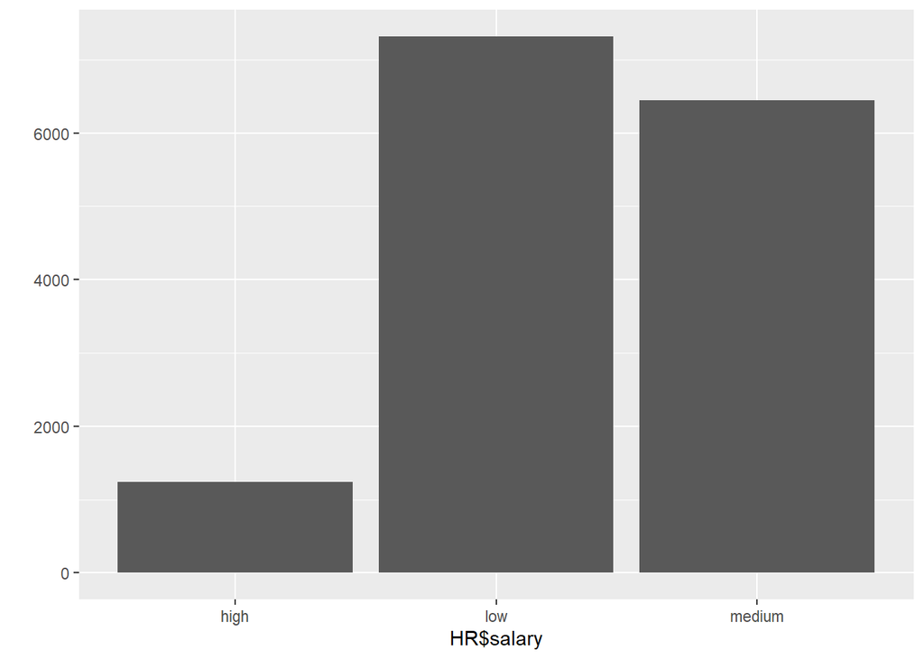

```r
qplot(HR$salary)
```

```r
table(HR$SL)
```

```
##
## 0.09  0.1 0.11 0.12 0.13 0.14 0.15 0.16 0.17 0.18 0.19  0.2 0.21 0.22 0.23 0.24
##  195  358  335   30   54   73   76   79   72   63   74   69   67   60   54   80
## 0.25 0.26 0.27 0.28 0.29  0.3 0.31 0.32 0.33 0.34 0.35 0.36 0.37 0.38 0.39  0.4
##   34   30   30   31   38   39   59   50   36   48   37  139  241  189  175  209
## 0.41 0.42 0.43 0.44 0.45 0.46 0.47 0.48 0.49  0.5 0.51 0.52 0.53 0.54 0.55 0.56
##  171  155  224  211  203   95   42  149  209  229  187  196  179  185  179  187
## 0.57 0.58 0.59  0.6 0.61 0.62 0.63 0.64 0.65 0.66 0.67 0.68 0.69  0.7 0.71 0.72
##  210  182  219  193  208  188  209  187  199  228  177  162  209  205  171  230
## 0.73 0.74 0.75 0.76 0.77 0.78 0.79  0.8 0.81 0.82 0.83 0.84 0.85 0.86 0.87 0.88
##  246  257  226  234  252  241  217  222  220  241  234  247  207  200  225  187
## 0.89  0.9 0.91 0.92 0.93 0.94 0.95 0.96 0.97 0.98 0.99    1
##  237  220  224  198  169  167  181  203  176  183  172  111
```

```r
summary(HR$SL)
```

```
##    Min. 1st Qu.  Median    Mean 3rd Qu.    Max.
##  0.0900  0.4400  0.6400  0.6128  0.8200  1.0000
```

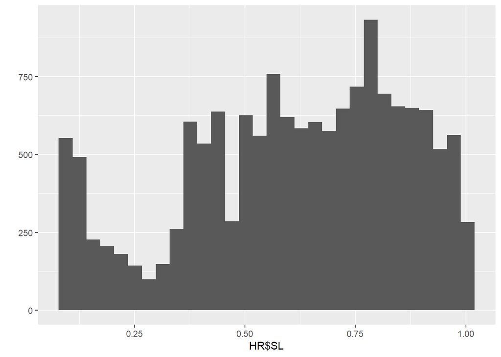

```r
qplot(HR$SL)
```

#### 평균표 만들기

```r
salary_SL <- HR %>%
  group_by(sales, salary) %>%
  summarise(mean_SL = mean(SL), .groups = 'drop')

salary_SL
```

```
## # A tibble: 30 x 3
##    sales      salary mean_SL
##    <chr>      <chr>    <dbl>
##  1 accounting high     0.614
##  2 accounting low      0.574
##  3 accounting medium   0.584
##  4 hr         high     0.673
##  5 hr         low      0.609
##  6 hr         medium   0.580
##  7 IT         high     0.638
##  8 IT         low      0.610
##  9 IT         medium   0.624
## 10 management high     0.653
## # ... with 20 more rows
```

#### 그래프 만들기

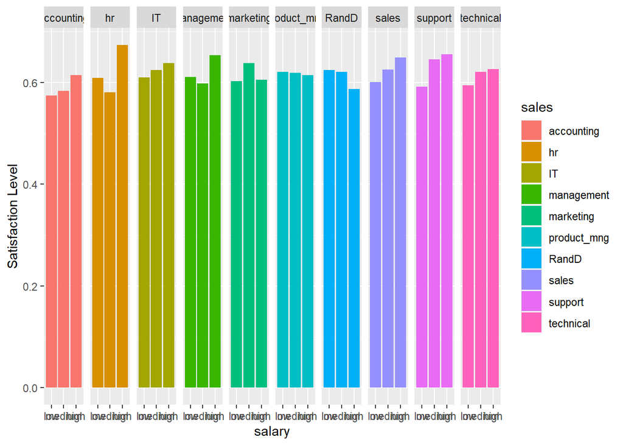

```r
ggplot(data = salary_SL, aes(x = salary, y = mean_SL, fill = sales)) +
  geom_col(position = "dodge") +
  facet_grid(~sales) +
  scale_x_discrete(limits = c("low", "medium", "high")) +
  scale_y_continuous("Satisfaction Level")
```

#### 결과 분석

# 2. 부서별 이직률과 임금의 상관관계 : 임금이 높을수록 이직률 낮을 것

#### 변수 검토

```r
table(HR$left)
```

```
##
##     0     1
## 11428  3571
```

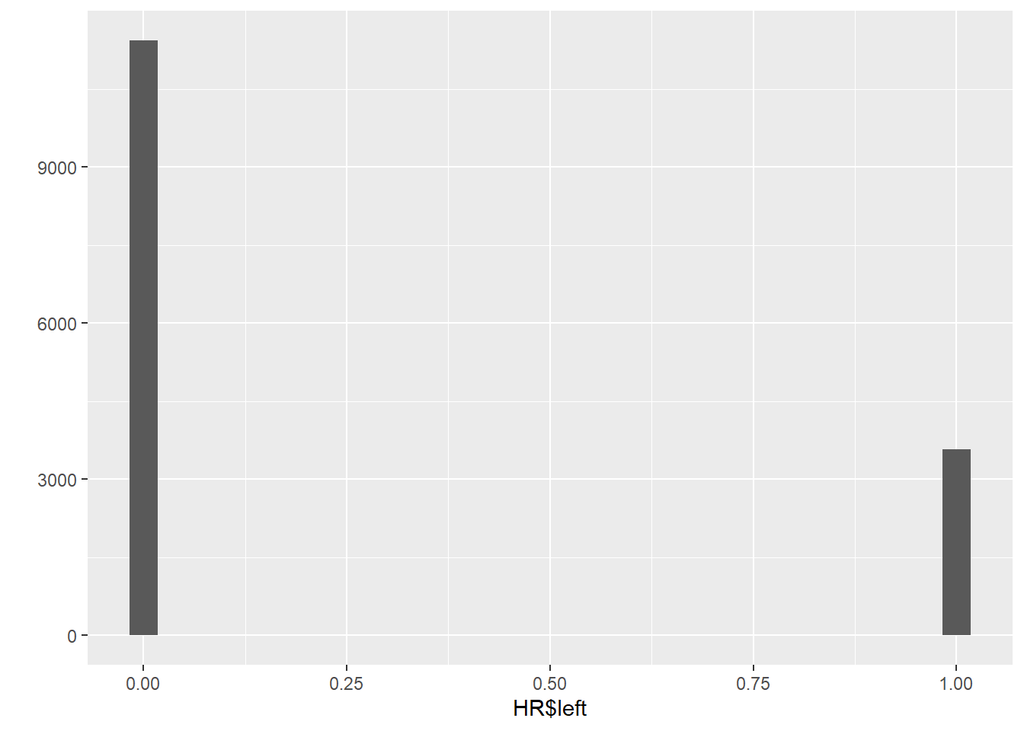

```r
qplot(HR$left)
```

#### 이직여부에 이름부여

```r
HR$left <- ifelse(HR$left == 0, "left", "turnover")
table(HR$left)
```

```
##
##     left turnover
##    11428     3571
```

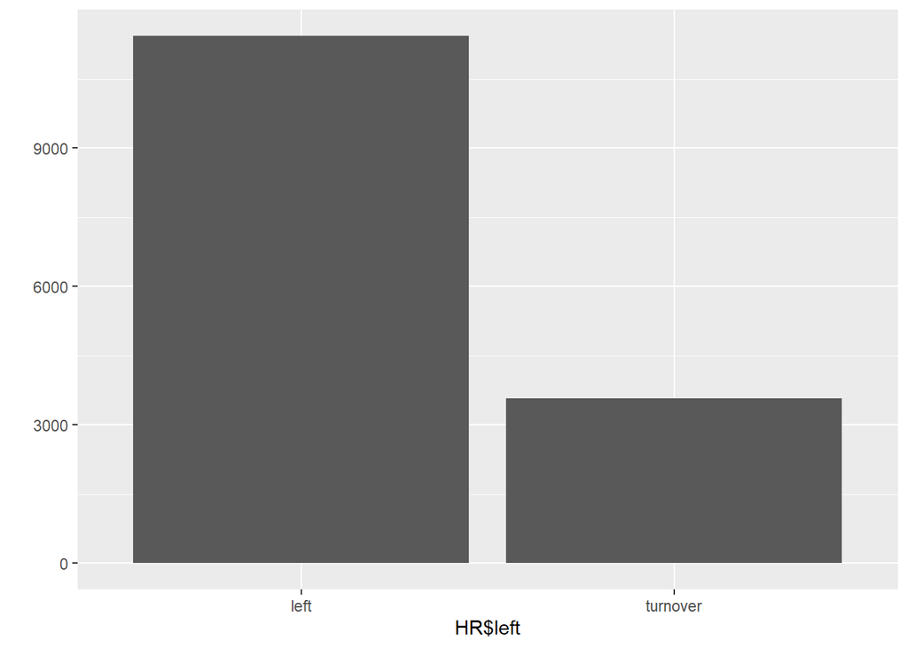

```r
qplot(HR$left)
```

#### 부서별, 이직률, 임금 비율표 만들기

```r
sales_salary_left <- HR %>%
  group_by(sales, salary, left) %>%
  summarise(n = n(),  .groups = 'drop') %>%
  mutate(tot_group = sum(n)) %>%
  mutate(pct = round(n/tot_group*100,1))

sales_salary_left
```

```
## # A tibble: 60 x 6
##    sales      salary left         n tot_group   pct
##    <chr>      <chr>  <chr>    <int>     <int> <dbl>
##  1 accounting high   left        69     14999   0.5
##  2 accounting high   turnover     5     14999   0
##  3 accounting low    left       259     14999   1.7
##  4 accounting low    turnover    99     14999   0.7
##  5 accounting medium left       235     14999   1.6
##  6 accounting medium turnover   100     14999   0.7
##  7 hr         high   left        39     14999   0.3
##  8 hr         high   turnover     6     14999   0
##  9 hr         low    left       243     14999   1.6
## 10 hr         low    turnover    92     14999   0.6
## # ... with 50 more rows
```

#### 부서별, 이직률, 임금 표 만들기

```r
df_turnover1 <- sales_salary_left %>%
  filter(left == "turnover") %>%
  select(sales, salary, pct)

df_turnover1
```

```
## # A tibble: 30 x 3
##    sales      salary   pct
##    <chr>      <chr>  <dbl>
##  1 accounting high     0
##  2 accounting low      0.7
##  3 accounting medium   0.7
##  4 hr         high     0
##  5 hr         low      0.6
##  6 hr         medium   0.8
##  7 IT         high     0
##  8 IT         low      1.1
##  9 IT         medium   0.6
## 10 management high     0
## # ... with 20 more rows
```

#### 그래프 만들기

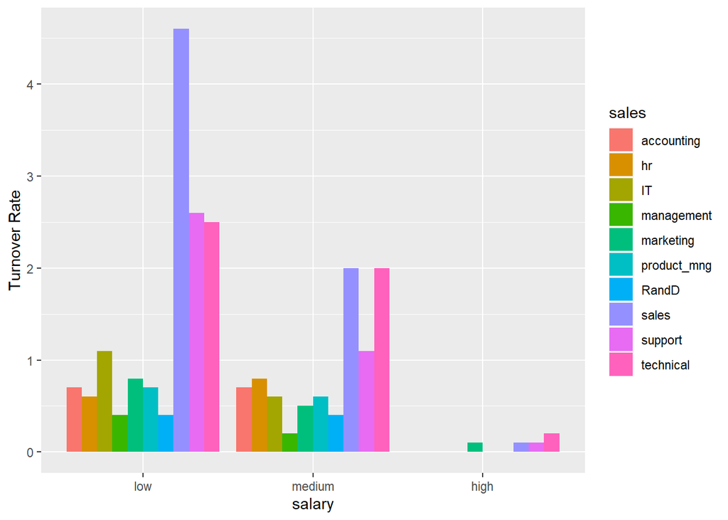

```r
ggplot(data = df_turnover1, aes(x = salary, y = pct, fill = sales)) +
  geom_col(position = "dodge") +
  scale_x_discrete(limits = c("low", "medium", "high")) +
#  scale_x_continuous("Salary") +
  scale_y_continuous("Turnover Rate")
```

# 3. 부서별 마지막 평가점수와 이직률 상관관계 : 마지막 평가 점수가 낮을수록 이직률 높을 것

## 변수검토

```r
class(HR$left)
```

```
## [1] "character"
```

```r
table(HR$left)
```

```
##
##     left turnover
##    11428     3571
```

```r
class(HR$LE)
```

```
## [1] "numeric"
```

```r
summary(HR$LE)
```

```
##    Min. 1st Qu.  Median    Mean 3rd Qu.    Max.
##  0.3600  0.5600  0.7200  0.7161  0.8700  1.0000
```

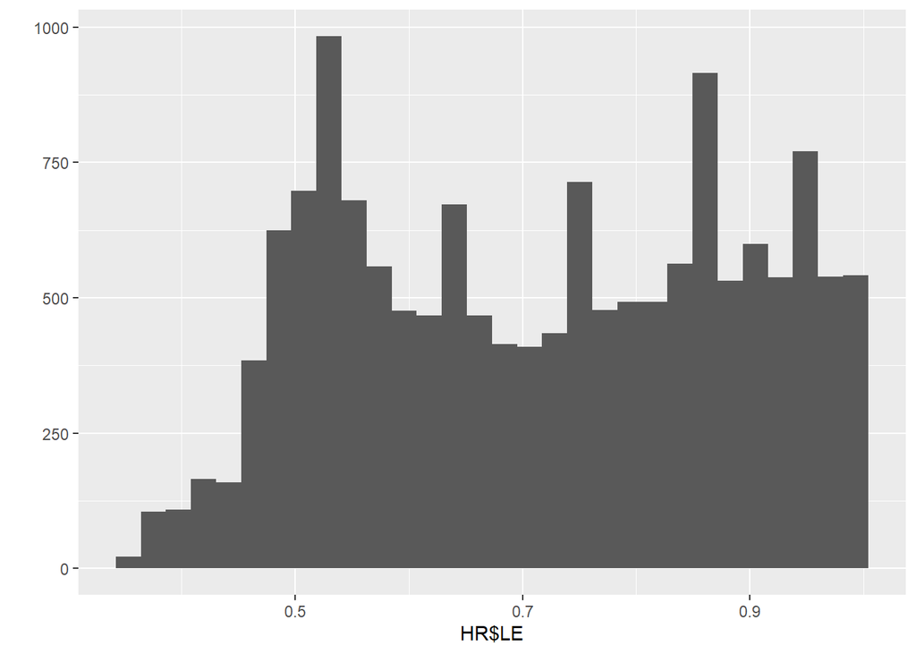

```r
qplot(HR$LE)
```

#### 부서별, 이직률, 마지막평가점수 비율표만들기

```r
sales_LE_left <- HR %>%
  group_by(sales, LE, left) %>%
  summarise(n = n(), .groups = 'drop') %>%
  mutate(tot_group = sum(n)) %>%
  mutate(pct = round(n/tot_group*100,1))
```

#### 부서별, 이직률, 마지막평가점수 표만들기

```r
df_turnover2 <- sales_LE_left %>%
  filter(left == "turnover") %>%
  select(sales, LE, pct)

df_turnover2
```

```
## # A tibble: 383 x 3
##    sales         LE   pct
##    <chr>      <dbl> <dbl>
##  1 accounting  0.45   0
##  2 accounting  0.46   0.1
##  3 accounting  0.47   0.1
##  4 accounting  0.48   0.1
##  5 accounting  0.49   0.1
##  6 accounting  0.5    0.1
##  7 accounting  0.51   0
##  8 accounting  0.52   0
##  9 accounting  0.53   0.1
## 10 accounting  0.54   0
## # ... with 373 more rows
```

#### 그래프 만들기

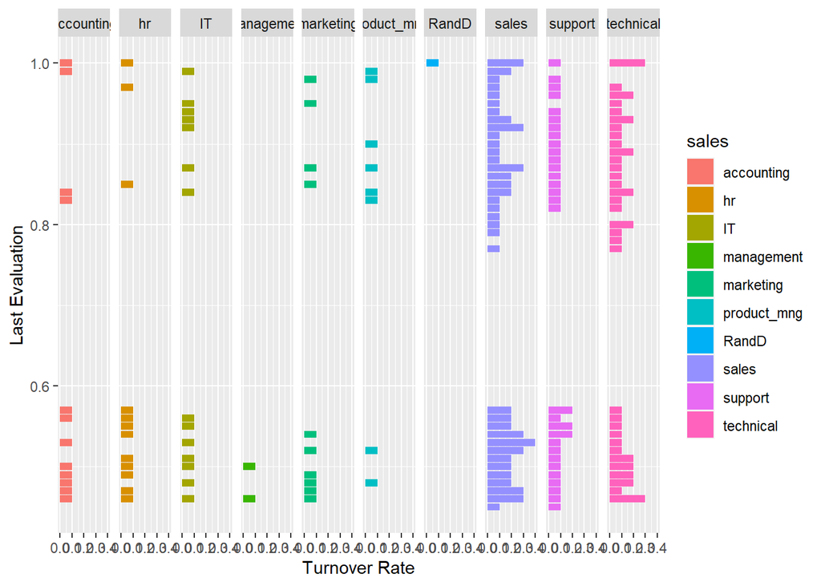

```r
ggplot(data = df_turnover2, aes(x = LE, y = pct, fill = sales)) +
  geom_col(position = "dodge") +
  coord_flip() +
  facet_grid(~sales) +
  scale_x_continuous("Last Evaluation") +
  scale_y_continuous("Turnover Rate")
```

# 4. 이직률과 진행 프로젝트 개수 상관관계 : 프로젝트 개수가 많을수록 이직률이 높을 것

#### 변수 검토

```r
table(HR$NP)
```

```
##
##    2    3    4    5    6    7
## 2388 4055 4365 2761 1174  256
```

```r
summary(HR$NP)
```

```
##    Min. 1st Qu.  Median    Mean 3rd Qu.    Max.
##   2.000   3.000   4.000   3.803   5.000   7.000
```

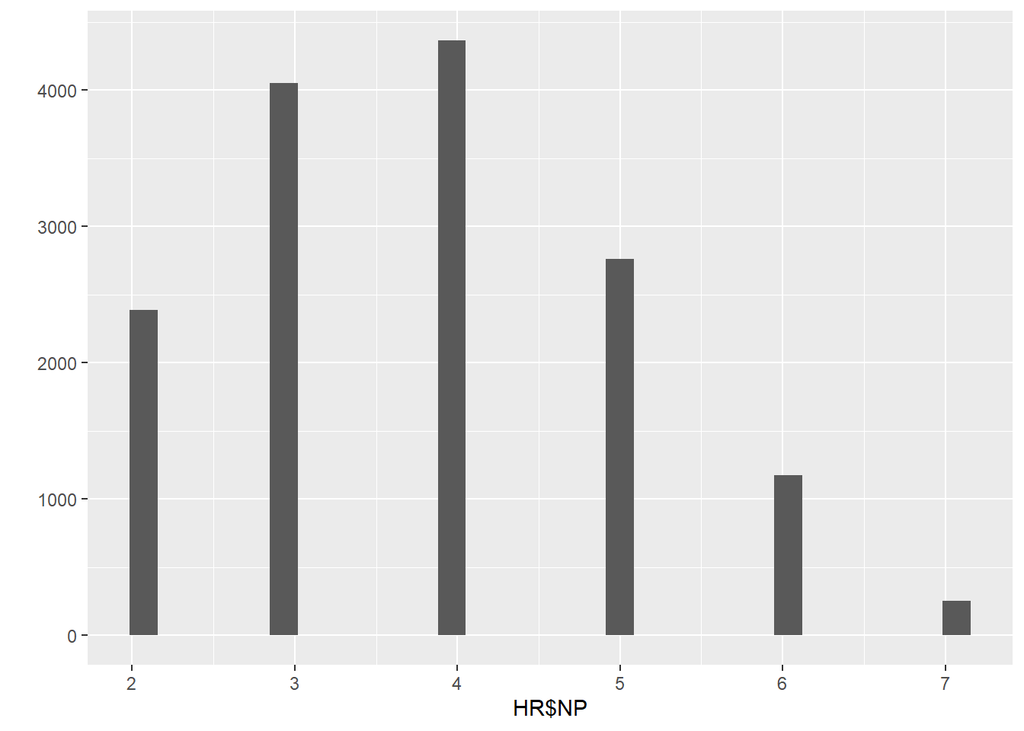

```r
qplot(HR$NP)
```

#### 평균표 만들기

```r
left_NP <- HR %>%
  group_by(sales, left, NP) %>%
  summarise(n = n(), .groups='drop') %>%
  mutate(tot_group = sum(n)) %>%
  mutate(pct = round(n/tot_group*100,1))

left_NP
```

```
## # A tibble: 109 x 6
##    sales      left        NP     n tot_group   pct
##    <chr>      <chr>    <int> <int>     <int> <dbl>
##  1 accounting left         2    35     14999   0.2
##  2 accounting left         3   197     14999   1.3
##  3 accounting left         4   193     14999   1.3
##  4 accounting left         5   117     14999   0.8
##  5 accounting left         6    21     14999   0.1
##  6 accounting turnover     2    91     14999   0.6
##  7 accounting turnover     3     2     14999   0
##  8 accounting turnover     4    28     14999   0.2
##  9 accounting turnover     5    23     14999   0.2
## 10 accounting turnover     6    45     14999   0.3
## # ... with 99 more rows
```

```r
df <-as.data.frame(left_NP)
```

#### 그래프 만들기

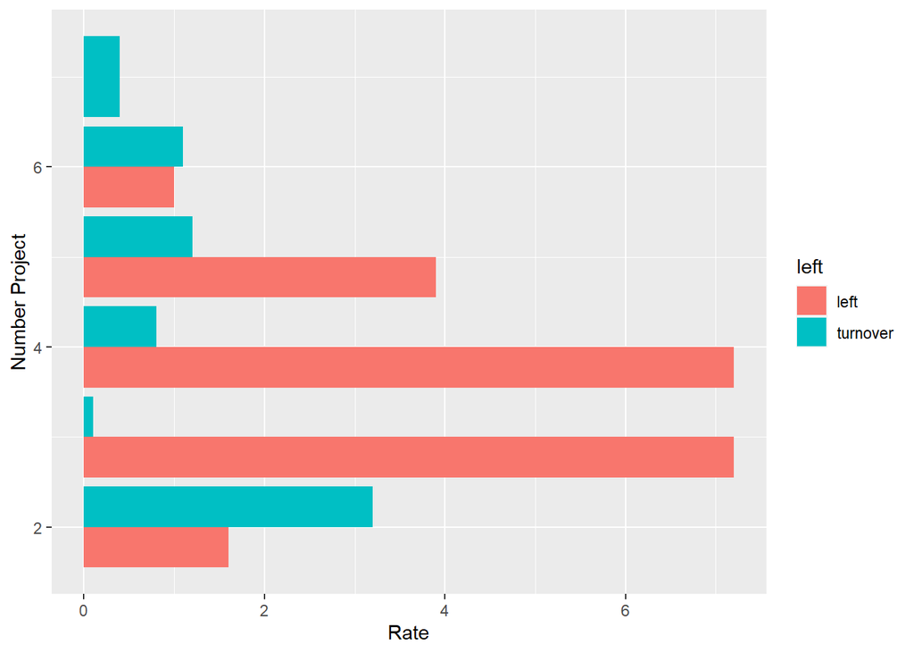

```r
ggplot(data = df, aes(x = NP, y = pct, fill = left)) +
  geom_col(position="dodge") +
  coord_flip() +
  scale_x_continuous("Number Project") +
  scale_y_continuous("Rate")
```

#### 결과 분석

# 5. 부서별 근속연수에 따른 직무 만족도 : 근속년수가 길수록 직무 만족도가 높을 것

#### 변수검토

```r
table(HR$TS)
```

```
##
##    2    3    4    5    6    7    8   10
## 3244 6443 2557 1473  718  188  162  214
```

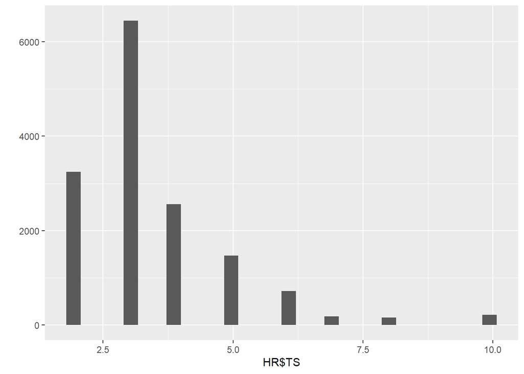

```r
qplot(HR$TS)
```

```r
table(HR$SL)
```

```
##
## 0.09  0.1 0.11 0.12 0.13 0.14 0.15 0.16 0.17 0.18 0.19  0.2 0.21 0.22 0.23 0.24
##  195  358  335   30   54   73   76   79   72   63   74   69   67   60   54   80
## 0.25 0.26 0.27 0.28 0.29  0.3 0.31 0.32 0.33 0.34 0.35 0.36 0.37 0.38 0.39  0.4
##   34   30   30   31   38   39   59   50   36   48   37  139  241  189  175  209
## 0.41 0.42 0.43 0.44 0.45 0.46 0.47 0.48 0.49  0.5 0.51 0.52 0.53 0.54 0.55 0.56
##  171  155  224  211  203   95   42  149  209  229  187  196  179  185  179  187
## 0.57 0.58 0.59  0.6 0.61 0.62 0.63 0.64 0.65 0.66 0.67 0.68 0.69  0.7 0.71 0.72
##  210  182  219  193  208  188  209  187  199  228  177  162  209  205  171  230
## 0.73 0.74 0.75 0.76 0.77 0.78 0.79  0.8 0.81 0.82 0.83 0.84 0.85 0.86 0.87 0.88
##  246  257  226  234  252  241  217  222  220  241  234  247  207  200  225  187
## 0.89  0.9 0.91 0.92 0.93 0.94 0.95 0.96 0.97 0.98 0.99    1
##  237  220  224  198  169  167  181  203  176  183  172  111
```

```r
summary(HR$SL)
```

```
##    Min. 1st Qu.  Median    Mean 3rd Qu.    Max.
##  0.0900  0.4400  0.6400  0.6128  0.8200  1.0000
```

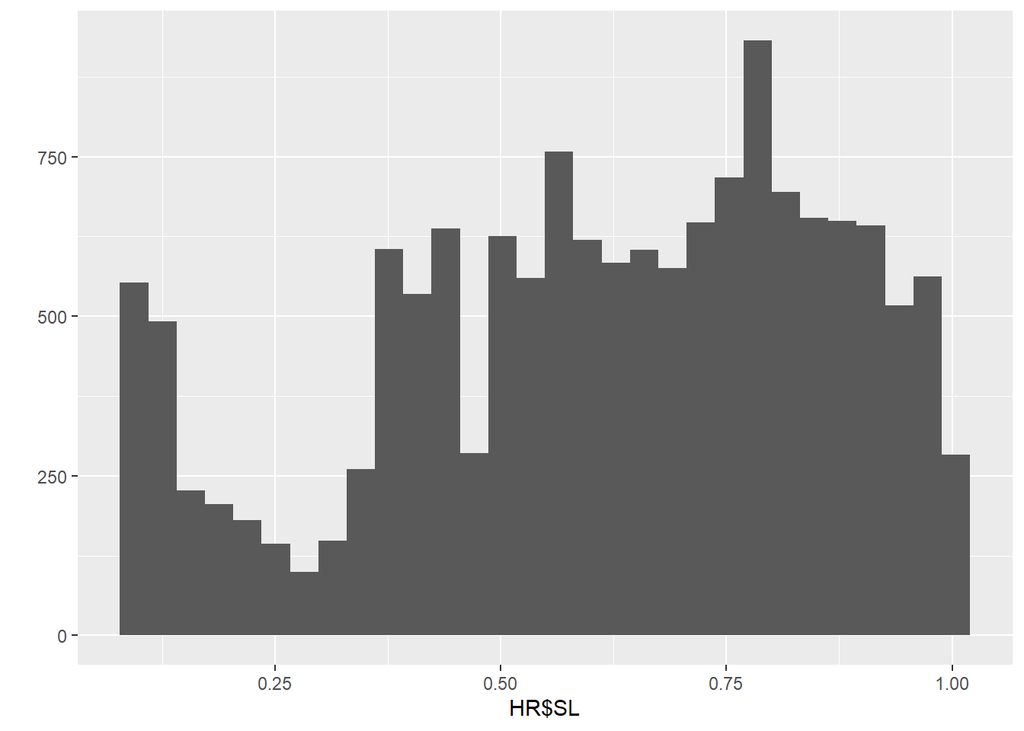

```r
qplot(HR$SL)
```

#### 평균표 만들기

```r
TS_SL <- HR %>%
  group_by(sales, TS) %>%
  summarise(mean_SL = mean(SL), .groups = 'drop')

TS_SL
```

```
## # A tibble: 74 x 3
##    sales         TS mean_SL
##    <chr>      <int>   <dbl>
##  1 accounting     2   0.686
##  2 accounting     3   0.606
##  3 accounting     4   0.427
##  4 accounting     5   0.574
##  5 accounting     6   0.565
##  6 accounting     8   0.693
##  7 accounting    10   0.752
##  8 hr             2   0.718
##  9 hr             3   0.594
## 10 hr             4   0.493
## # ... with 64 more rows
```

#### 그래프 만들기

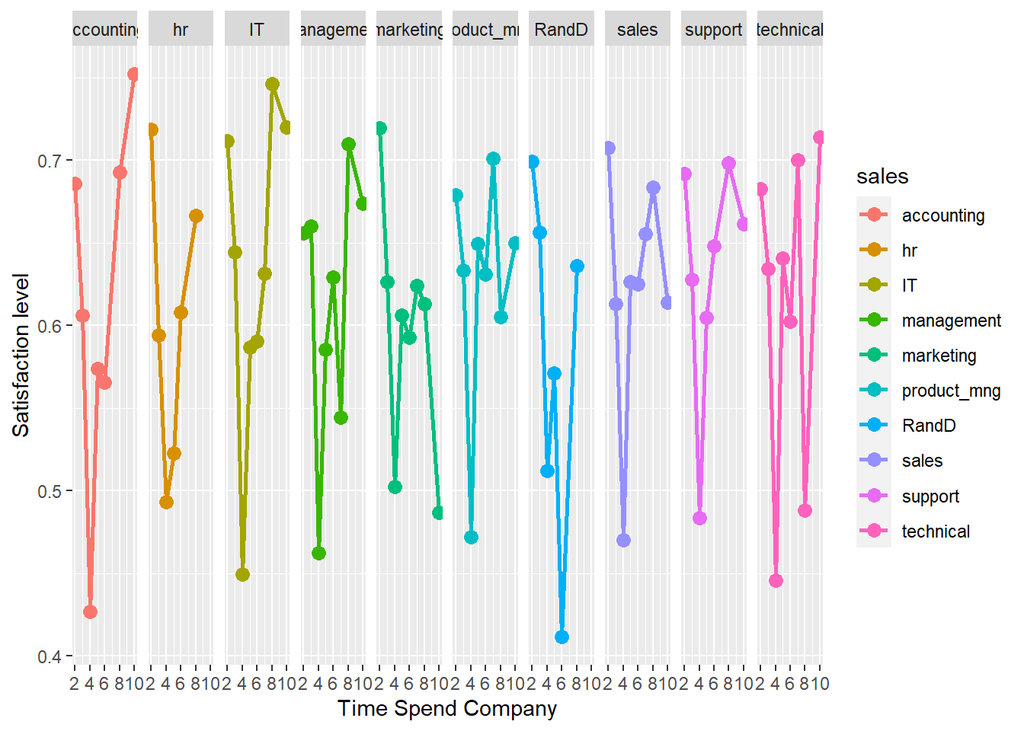

```r
ggplot(data = TS_SL, aes(x = TS, y = mean_SL, col = sales)) +
  geom_line(size = 1) +
  geom_point(size = 3) +
  facet_grid(~sales) +
  scale_x_continuous("Time Spend Company") +
  scale_y_continuous("Satisfaction level")
```

#### 결과 분석

- 전반적으로 직무 만족도 수준이 하강하다 상승하는 추세를 보임(v, w자형)
- 4-7년 차의 직무 만족도가 떨어지므로 보상휴가 등을 줘야함